# Spatial residencial segregation in Maryland

# Lesson Goals

In this lesson I will show you how to do Segregation Analysis with PySAL library. PySAL is a Python Spatial Analysis Library. This analysis will provide an insight for business and political opportunities.

# Prerequests

1. Install geopandas
2. install pySal

   NB:make sure you start your work with new directory will all library

```python
%load_ext watermark
```

```python
import geopandas as gpd
```

## Data Preparation

```python
mary = gpd.read_file("C:/Users/agurm/Downloads/pysal-scipy20-master/Maryland_Census/Maryland_Census_Data_-_Census_Tracts.shp")
```

We need to reproject the data into a more appropriate coordinate system. NAD83 should work

```python
mary = mary.to_crs(epsg=2248)
mary.crs
```

```
<Projected CRS: EPSG:2248>
Name: NAD83 / Maryland (ftUS)
Axis Info [cartesian]:
- X[east]: Easting (US survey foot)
- Y[north]: Northing (US survey foot)
Area of Use:
- name: USA - Maryland
- bounds: (-79.49, 37.97, -74.97, 39.73)
Coordinate Operation:
- name: SPCS83 Maryland zone (US Survey feet)
- method: Lambert Conic Conformal (2SP)
Datum: North American Datum 1983
- Ellipsoid: GRS 1980
- Prime Meridian: Greenwich
```

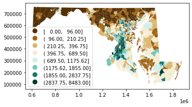

```python
mary.dropna(subset=['NHB']).plot(column='NHB',
                                                scheme='quantiles',
                                                cmap='BrBG',
                                                k=8,
                                                legend=True, legend_kwds={'loc': 'lower left'});
```

```python
mary.head()
```

|  | OBJECTID_1 | FID_TL_201 | ALAND10 | AWATER10 | CNTY2010 | CT10 | CT2010 | GEODESC | ACRES | SQ_MILES | ... | PLT18SP | CNTY20101 | CT101 | ACRES_1 | SQMILES | PSQM | REPORT_2_P | REPORT_9_P | Production | geometry |
| --- | --- | --- | --- | --- | --- | --- | --- | --- | --- | --- | --- | --- | --- | --- | --- | --- | --- | --- | --- | --- | --- |
| 0 | 1 | 0 | 170616683 | 5541577 | 24029 | 950100 | 24029950100 | 9501.00 | 42392.60956 | 66.23845 | ... | 27.8 | 24029 | 950100 | 42392.60956 | 66.23845 | 57.94 | http://mdpgis.mdp.state.md.us/Census2010/PDF/0... | http://mdpgis.mdp.state.md.us/Census2010/PDF/0... | 0 | MULTIPOLYGON (((1660989.634 625455.391, 166109... |
| 1 | 2 | 1 | 279186393 | 29289092 | 24029 | 950200 | 24029950200 | 9502.00 | 69542.40176 | 108.66000 | ... | 30.8 | 24029 | 950200 | 69542.40176 | 108.66000 | 44.58 | http://mdpgis.mdp.state.md.us/Census2010/PDF/0... | http://mdpgis.mdp.state.md.us/Census2010/PDF/0... | 0 | MULTIPOLYGON (((1617048.609 619653.618, 161701... |
| 2 | 3 | 2 | 21445745 | 1762900 | 24029 | 950300 | 24029950300 | 9503.00 | 5332.72370 | 8.33238 | ... | 47.0 | 24029 | 950300 | 5332.72370 | 8.33238 | 693.08 | http://mdpgis.mdp.state.md.us/Census2010/PDF/0... | http://mdpgis.mdp.state.md.us/Census2010/PDF/0... | 0 | POLYGON ((1583363.908 580319.641, 1583401.870 ... |
| 3 | 4 | 3 | 72736967 | 56708716 | 24029 | 950500 | 24029950500 | 9505.00 | 18197.97926 | 28.43434 | ... | 37.0 | 24029 | 950500 | 18197.97926 | 28.43434 | 92.25 | http://mdpgis.mdp.state.md.us/Census2010/PDF/0... | http://mdpgis.mdp.state.md.us/Census2010/PDF/0... | 0 | MULTIPOLYGON (((1545677.831 553946.926, 154569... |
| 4 | 5 | 4 | 173519483 | 33126235 | 24029 | 950400 | 24029950400 | 9504.00 | 43502.34671 | 67.97242 | ... | 38.1 | 24029 | 950400 | 43502.34671 | 67.97242 | 45.86 | http://mdpgis.mdp.state.md.us/Census2010/PDF/0... | http://mdpgis.mdp.state.md.us/Census2010/PDF/0... | 0 | MULTIPOLYGON (((1547307.029 585802.872, 154742... |

5 rows × 46 columns

```python
mary.columns
```

```
Index(['OBJECTID_1', 'FID_TL_201', 'ALAND10', 'AWATER10', 'CNTY2010', 'CT10',
       'CT2010', 'GEODESC', 'ACRES', 'SQ_MILES', 'POP100', 'HU100', 'NHW',
       'NHB', 'NHAI', 'NHA', 'NHNH', 'NHO', 'NHT', 'HISP', 'PNHW', 'PNHB',
       'PNHAI', 'PNHA', 'PNHNH', 'PNHO', 'PNHT', 'PHISP', 'POP65_',
       'PCTPOP65_', 'MEDAGE', 'VACNS', 'PVACNS', 'PHOWN', 'PWOMORT', 'PRENT',
       'PLT18SP', 'CNTY20101', 'CT101', 'ACRES_1', 'SQMILES', 'PSQM',
       'REPORT_2_P', 'REPORT_9_P', 'Production', 'geometry'],
      dtype='object')
```